# Stationary Profiles Unsaturated Zone

# 1 The Richards equation

The Richards equation is a partial differential equation that describes the flow of water in unsaturated soils. Flow in the unsaturated zone is predominantly vertical so here we only consider flow in the $z$ direction equation.

$$\frac{\partial \theta}{\partial t} =
-\frac{\partial q}{\partial z} - S\\ \frac{\partial \theta}{\partial t}
= \frac{\partial}{\partial z} \left\{ K(\psi) \left ( \frac{\partial
\psi}{\partial z} +1 \right) \right\} -S$$

Where:

$\theta : \text{moisture content (L/L)}$

$q : \text{flux rate (L/T)}$

$S : \text{source and or sinks (/T)}$

$K : \text{hydraulic conductivity (L/T)}$

$\psi : \text{pressure (L)}$

## 1.1 The Retention curves

The moisture content and pressure head are closely related to each other. The retention curve is a plot of the moisture content as a function of the pressure head. The pressure head is negative in the unsaturated zone.

Some preliminaries to clean the environment and load soil data

```
#cleasing the workspace
rm(list=ls())
#loading some packages
library(knitr)
#preprogrammed soil data
#loading the
load("Staring.RData")
print(paste("Soil type: ",names(soil.set)," ",lapply(soil.set, function(x) x$name)))
```

```
 [1] "Soil type:  B1   Non-loamy sand"       "Soil type:  B2   Loamy sand"           "Soil type:  B3   Very loamy sand"
 [4] "Soil type:  B4   Extremely loamy sand" "Soil type:  B5   Coarse sand"          "Soil type:  B6   Boulder clay"
 [7] "Soil type:  B7   Sandy loam"           "Soil type:  B8   Silt loam"            "Soil type:  B9   Clayey loam"
[10] "Soil type:  B10   Light clay"          "Soil type:  B11   Heavy clay"          "Soil type:  B12   Very heavy clay"
[13] "Soil type:  B13   Loam"                "Soil type:  B14   Heavy loam"          "Soil type:  B15   Peaty sand"
[16] "Soil type:  B16   Sandy peat"          "Soil type:  B17   Peaty clay"          "Soil type:  B18   Clayey peat"
[19] "Soil type:  O1   Non-loamy sand"       "Soil type:  O2   Loamy sand"           "Soil type:  O3   Very loamy sand"
[22] "Soil type:  O4   Extremely loamy sand" "Soil type:  O5   Coarse sand"          "Soil type:  O6   Boulder clay"
[25] "Soil type:  O7   River loam"           "Soil type:  O8   Sandy loam"           "Soil type:  O9   Silt loam"
[28] "Soil type:  O10   Clayey loam"         "Soil type:  O11   Light clay"          "Soil type:  O12   Heavy clay"
[31] "Soil type:  O13   Very heavy clay"     "Soil type:  O14   Loam"                "Soil type:  O15   Heavy loam"
[34] "Soil type:  O16   Oligotrophic peat"   "Soil type:  O17   Eutrophic peat"      "Soil type:  O18   Peaty layer"
```

```
#kable(paste("Soil type: ",names(soil.set)," ",lapply(soil.set, function(x) x$name)))
```

Plotting the retention curve for a specific soil type, here B13; Loam.

The first plot is based on the suction values (y-axis) vs. moisture content (x-axis).

The second, more usual plot, is based on the pF vs. moisture content. De pF stands for the log10 of the pressure values in centimeters.

So a pF of 2 means -100 cm pressure, pF=3 equals to -1000 cm pressure.

```
#number of data points in pF range:
pF = seq(0.01,4.2,by=0.05)
psi = -10^(pF)
soil = soil.set$B13
plot(soil$theta.fun(psi),psi,type="l",col="red",lwd = 3,
     main = paste("Retention profile of",soil$name),
     ylab="Pressure head (cm)",xlab="Water content at equilibrium")
grid()
```

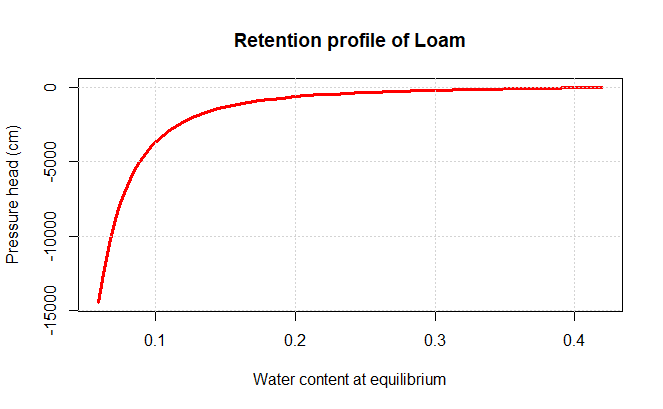

```
plot(soil$theta.fun(psi),log10(-psi),lwd = 3, type="l",col="red",
     main = paste("Retention profile of",soil$name),
     ylab="Pressure head in pF",xlab="Water content at equilibrium")
grid()
```

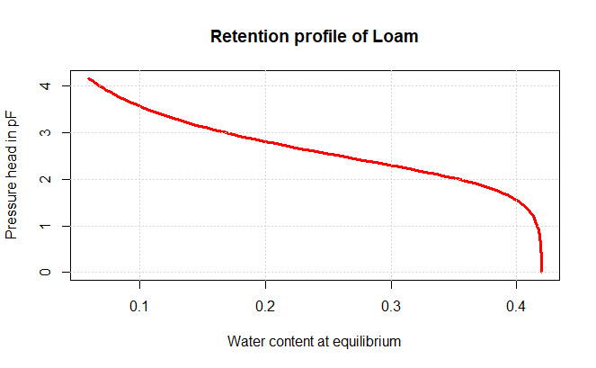

```
# library(plotly)
# p <- plot_ly(x = ~soil$k.fun(psi), y = ~log10(-psi), type = 'scatter', mode = 'lines',
#              line = list(color = 'red')) %>%
#   layout(title = 'Hydraulic Conductivity vs Pressure Head',
#          xaxis = list(title = 'Hydraulic conductivity'),
#          yaxis = list(title = 'Pressure head'))
#
# # Toon de plot
# p
```

## 1.2 The hydraulic conductivity

As shown in the Richards equation, the hydraulic conductivity is a function of pressure($K(\psi)$), which is negative in the unsaturated zone. However, it can also be expressed in terms of moisture content ($K(\theta)$) with the aid of the retention curve $\theta(\psi)$. [^1]

```
## K as function of psi
plot(soil$k.fun(psi),psi,type="l",lwd = 3,col="red",main = paste("K(psi) of soil:",soil$name),
     ylab="Pressure head (cm)",xlab="Hydraulic conductivity")
grid()
```

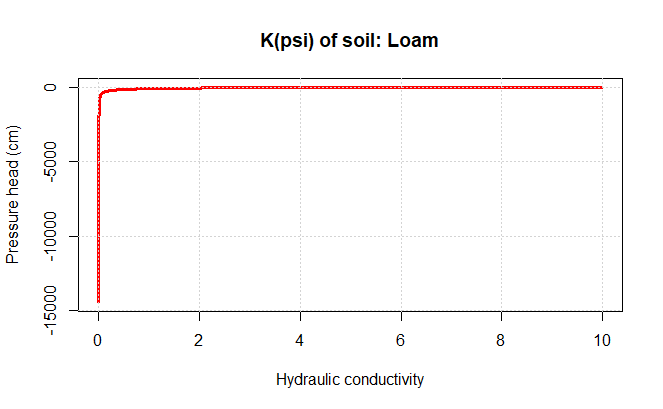

```
plot(soil$k.fun(psi),log10(-psi),lwd = 3, type="l",col="red",
     main = paste("K(psi) of soil:",soil$name),
     ylab="Pressure head in pF",xlab="Hydraulic conductivity")
grid()
```

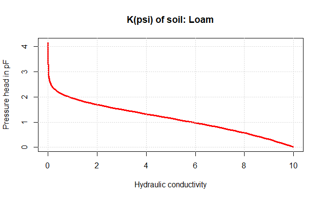

```
## K as function of theta

plot(soil$theta.fun(psi),soil$k.fun(psi),type = "l",lwd = 3,col="orange", main = paste("K(theta) of soil:",soil$name),
     ylab ="Hydraulic conductivity (cm/d)",
     xlab = "Moisture content (m/m)")
grid()
```

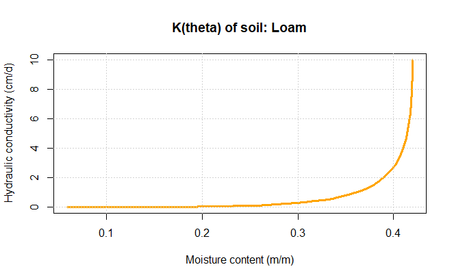

```
NA
NA
NA
```

## 1.3 Comparing a few soils

```
plot(soil.set$B13$theta.fun(psi),log10(-psi),type="l",col="red",lwd = 3,
     xlim = c(0.01,1),main = "Retention profiles",
     ylab="Pressure head (cm)",xlab="Water content at equilibrium")
lines(soil.set$B11$theta.fun(psi),log10(-psi),lwd = 3, col = "green")
```

```
lines(soil.set$O17$theta.fun(psi),log10(-psi), lwd = 3, col = "blue")
lines(soil.set$B5$theta.fun(psi),log10(-psi), lwd =3 , col = "brown")
```

```
grid()
##adding a legend to the plot
legend("topright", legend = c(soil.set$B13$name, soil.set$B11$name, soil.set$O17$name, soil.set$B5$name),
       col = c("red", "green", "blue", "brown"), lwd = 3)
```

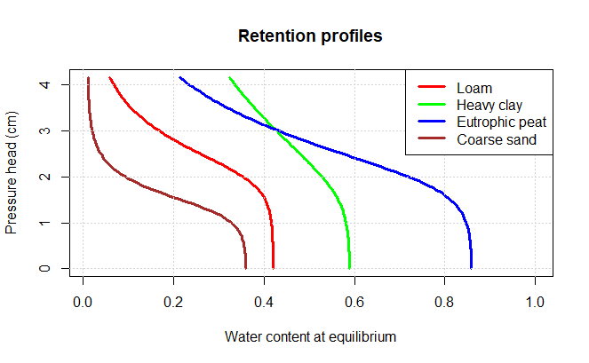

```
plot(soil.set$B13$k.fun(psi),log10(-psi),lwd = 3, type="l",col="red",
     main = "Hydraulic conductivity of some soils",
     xlim = c(0.0,soil.set$B5$ksat),
     ylab="Pressure head in pF",xlab="Hydraulic conductivity")
lines(soil.set$B11$k.fun(psi),log10(-psi),lwd = 3, col = "green")
```

```
lines(soil.set$O17$k.fun(psi),log10(-psi), lwd = 3, col = "blue")
lines(soil.set$B5$k.fun(psi),log10(-psi), lwd =3 , col = "brown")
```

```
grid()
##adding a legend to the plot
legend("topright", legend = c(soil.set$B13$name, soil.set$B11$name, soil.set$O17$name, soil.set$B5$name),
       col = c("red", "green", "blue", "brown"), lwd = 3)
```

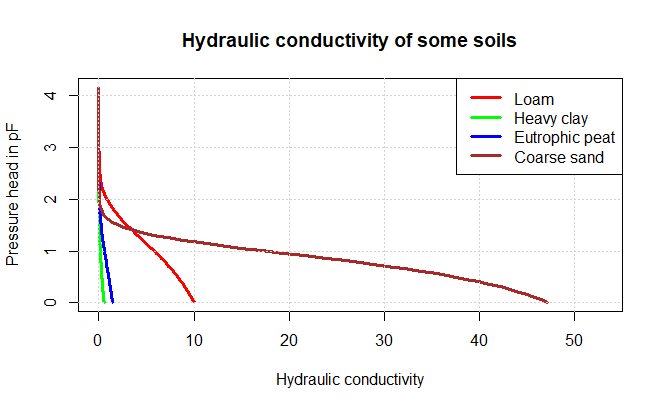

# 2 Stationary profiles

Here we will focus on the general behavior of flow in the unsaturated zone under stationary conditions for situations with deep and shallow groundwater tables and with different flux rates.

Since we only consider stationary flow, the time derivative is zero. The equation simplifies to:

$$0 = \frac{\partial q}{\partial z}$$

And since this *derivative* $\frac{\partial q}{\partial z}$ is, zero it means that the flux rate $q$, is now a constant. The equation (i.e. the Darcy Buckingham equation) becomes:

$$q =- K(\psi) \left ( \frac{\partial
\psi}{\partial z} +1 \right)$$

Given a certain soil type, thickness and flux rate, the pressure profile and, from that, the moisture profile can be determined.

### 2.0.1 Flow direction

Similar as with the ordinary Darcy equation, the minus sign indicates flow is opposite to the gradient direction. The physical interpretation of this is that flow is going towards the lowest pressure head. However, when calculating the derivative of the pressure head, this would result in a minus sign, turning the direction of flow.

In addition it is customary, in vadoze zone hydrology, to define the $z$ direction positive upwards. This results thus in a positive flux when flow is upwards and negative downward.

The following plot illustrates this;

- The dashed black line indicates equilibruim state, so no flow
- The red line illustrates a situation with a soil dryer than equilibrium so flow goes up (evaporation)
- The blue line illustrates a situation with a wetter soil, flow goes down, precipitation.

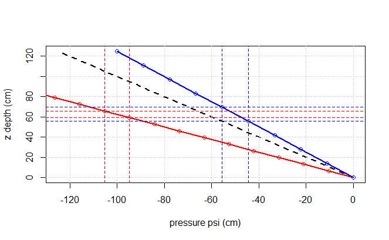

The two examples of pressure gradients the blue and red line will result in a flow down ($-q$) and up ($q$). A numerical example data is shown below. The positions; $Z(\psi)$’s, to calculate the gradient and its sign (so flow direction), is shown by the crossings of the red and blue dashed lines and are calculated at about 55 ~ 70 cm below surface:

```
[1] "delta psi dry: -94.7368421052632  -  -105.263157894737 = 10.5263157894737"
[1] "delta z dry: 59.2105263157895 - 65.7894736842105 = -6.57894736842105"
[1] "d_psi_dry/d_z_dry =  -1.6"
[1] "-K*{ -1.6 +1}; q=+/+ flow goes up"
[1] "delta psi wet: -44.4444444444444  -  -55.5555555555556 = 11.1111111111111"
[1] "delta z wet: 55.5555555555556 - 69.4444444444444 = -13.8888888888889"
[1] "d_psi_wet/d_z_wet =  -0.8"
[1] "-K*{ -0.8 +1}; q=-/- flow goes down"
```

## 2.1 Procedure

1. Define the soil type
2. Define the domain of the model
3. Define the boundary conditions
4. Solve the equation

### 2.1.1 Soil type

Choose one of the soil types given in the `soil.set` object.

Each soil type, within the `soil.set` contains several specifiek properties important for modeling flow in the unsaturated zone. As an example the properties, numbers, a name and functions, of a loamy sand `soil.set$B2`

```
print(unlist(soil.set$B2))
```

```
$soiltype
[1] "B2"

$theta.res
[1] 0.02

$theta.sat
[1] 0.42

$n
[1] 1.491

$alpha
[1] 0.0276

$ksat
[1] 12.52

$lambda
[1] -1.06

$name
[1] "Loamy sand"

$k.fun
function (v)
.approxfun(x, y, v, method, yleft, yright, f)
<environment: 0x000001eb545efb08>

$theta.fun
function (v)
.approxfun(x, y, v, method, yleft, yright, f)
<environment: 0x000001eb545f0518>

$c.fun
function (v)
.approxfun(x, y, v, method, yleft, yright, f)
<environment: 0x000001eb545ee070>

$Richards.flux
function(x,state,gradstate)
                        {
                          return(-soil.set$B2$k.fun(state)*(gradstate+1))
                        }
```

### 2.1.2 Domain

Since we are interested in the effect of large and small unsaturated zones the domains reasonable sizes for large unsaturated zones are 4 - 25 m, and 0.5-2 m for small unsaturated zones. Large zones are located at ice pushed ridges and small ones in valleys close to a brook or river.

Here we are going to apply an explicit scheme to calculate the pressure head (i.e. $\psi$) in the unsaturated zone. The differential in the (Darcy like) equation is now approximated by a finite differences:

$$\frac{\partial \psi}{\partial z} \approx
\frac{\psi_{z}-\psi_{z-\Delta z}}{\Delta z}$$

Rewrite the Darcy alike question into a finite difference equation that calculates the pressure head at depth $z$, based on all the other terms.

$$q = -K(\psi) \left (
\frac{\psi_z-\psi_{z-\Delta z}}{\Delta z} +1\right )\\
\psi_{z} = \psi_{z-\Delta z} - \left( \frac{q_{z}}{K(\psi_{z-\Delta
z})} + 1 \right)\Delta z$$

# 3 Implementation

Since the retetention curves are quite non-linear it is practical to have not too large steps ($\Delta z$) in the domain. Start with $\Delta z= 1 cm$

It is custom in the vadoze zone hydrology to use centimeters for the spatial scale. So the flux rate is given in cm/day. The hydraulic conductivity is given in cm/day. The pressure head is given in cm.

Add the explicit scheme (at the xxxxxxxxxxxxxxxx) to calculate the pressure head in the unsaturated zone.

```r
#defining the soil type
#soil = soil.set$B13
soil = soil.set$O2
soil_name = soil$name

#DEFINING THE FLOW DOMAIN
#BE AWARE Z=0 is at the groundwater table Z=Duns is at the surface
#Z-direction is positive upwards
dz = 1 #cm small steps are required
Duns = 1500 # Thickness of the usaturated zone
psi = seq(0,Duns,by=dz) #a vector for psi profile cm
z = psi # a vector for the depth

###BOUNDARY CONDITIONS
#at the groundwater table the pressure head psi is 0.0
psi[1] = 0.0
#at the surface the flux rate is given
q = -0.01 #cm/day

###CALCULATING THE PRESSURE HEADS with an explicit scheme

for (i in 2:length(psi)){

    psi[i] = xxxxxxxxxxxxxxxxxxxxxxx

}

###PLOTTING THE RESULTS
oldpar = par(no.readonly = TRUE)

par(mfrow=c(1,2)) #this creates two plots next to each other

plot(-z,z,type= "l",lty= "dashed",col="blue",main = paste(soil_name,"; q = ",q,"cm/day"),
     ylab="Depth (cm)",xlab="Pressure head (psi in cm)",xlim=range(psi))
lines(psi,z,type="l",lwd = 3,col="red")
grid()

range_theta = c(soil$theta.res,soil$theta.sat)
plot(soil$theta.fun(psi),z,type="l",lwd = 3,col="red",
     ylab="Depth (cm)",xlab="Water content",xlim=range_theta)
lines(soil$theta.fun(-z),z,lty="dashed",col="blue")
grid()
par(oldpar)
```

Below the code for generating stationary profiles.

```
#defining the soil type
#soil = soil.set$B13
soil = soil.set$O2
soil_name = soil$name

#DEFINING THE FLOW DOMAIN
#BE AWARE Z=0 is at the groundwater table Z=Duns is at the surface
#Z-direction is positive upwards
dz = 1 #cm small steps are required
Duns = 1500 # Thickness of the usaturated zone
psi = seq(0,Duns,by=dz) #a vector for psi profile cm
z = psi # a vector for the depth

###BOUNDARY CONDITIONS
#at the groundwater table the pressure head psi is 0.0
psi[1] = 0.0
#at the surface the flux rate is given
q = -0.01 #cm/day

###CALCULATING THE PRESSURE HEADS with an explicit scheme

for (i in 2:length(psi)){

    psi[i] = psi[i-1] - dz * (q/soil$k.fun(psi[i-1])+1)

}

###PLOTTING THE RESULTS
oldpar = par(no.readonly = TRUE)

par(mfrow=c(1,2)) #this creates two plots next to each other

plot(-z,z,type= "l",lty= "dashed",col="blue",main = paste(soil_name,"; q = ",q,"cm/day"),
     ylab="Depth (cm)",xlab="Pressure head (psi in cm)",xlim=range(psi))
lines(psi,z,type="l",lwd = 3,col="red")
```

```
grid()

range_theta = c(soil$theta.res,soil$theta.sat)
plot(soil$theta.fun(psi),z,type="l",lwd = 3,col="red",
     ylab="Depth (cm)",xlab="Water content",xlim=range_theta)
```

```
lines(soil$theta.fun(-z),z,lty="dashed",col="blue")
grid()
```

```
par(oldpar)
```

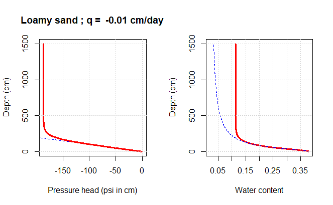

Checking the flux rate.

Since we now have calculated the $\frac{\Delta \psi}{\Delta z}$ , we can easily calculate back the flux rate $q$.

Calculate the flux rate in the unsaturated zone.

TIP: use the ” diff ” function to determine the pressure gradient in the profile TIP2: you may also check the flux rate at some locations, e.g. on top, half-way at the bottom

```
#q = -k(psi)(dpsi/dz + 1))
q = -soil$k.fun(psi[-length(psi)])*(diff(psi)/dz + 1)
range(q)
```

```
[1] -0.01 -0.01
```

1. What is the moisture content in de upper part of the unsaturated zone?
2. What is the hydraulic conductivity for this moisture content?
3. Can you argue that the $K(\theta)$ is equal to $q$?

The upper part of the profile is in the psi range of say `psi[1000]` till `psi[1500]`, with the `dz =` 1 (cm).

The moisture content is then simply be calculated by: `soil$theta(psi[1000:1500])`

The hydraulic conductivity at the same range can be calculated by:

`soil$k.fun(psi[1000:1500])`

```
theta = soil$theta.fun(psi[1000:1500])
print(paste("moisture content :",head(theta)))
```

```
[1] "moisture content : 0.113812650056737" "moisture content : 0.113812650015809" "moisture content : 0.113812649975658"
[4] "moisture content : 0.113812649936267" "moisture content : 0.113812649897622" "moisture content : 0.11381264985971"
```

```
k = soil$k.fun(psi[1000:1500])
print(paste("conductivity :",head(k)))
```

```
[1] "conductivity : 0.0100000009449386" "conductivity : 0.0100000009270348" "conductivity : 0.0100000009094701"
[4] "conductivity : 0.0100000008922383" "conductivity : 0.010000000875333"  "conductivity : 0.010000000858748"
```

```
print(paste("flux rate :",head(q)))
```

```
[1] "flux rate : -0.00999999999999994" "flux rate : -0.0100000000000002"  "flux rate : -0.00999999999999879"
[4] "flux rate : -0.00999999999999939" "flux rate : -0.00999999999999827" "flux rate : -0.0100000000000043"
```

[^1]: Here we neglect effects of histeresis (soils turning from wet to dry do not describe the same moisture/pressure profiles as from soils turning dry from wet)